# Análisis de datos de RNA-Seq II

BioScienceApps

Estefania Mancini

18-21 de abril de 2022

## Comparación de 2 o más condiciones

Con este tipo de datos podemos hacernos diferentes preguntas o contrastes. Un caso sencillo sería pensar 1 condición como control y comparar las demás contra esta o por ejemplo si hubiera un orden temporal.

En ese caso, por ejemplo tendriamos un caso donde hay un orden temporal de las muestras: NSC–>ENB–>LNB

Para eso, cargamos los datos y estimaremos los parámetros de dispersión teniendo en cuenta todas las condiciones juntas

Cargamos todos los paquetes que usaremos:

```r
library(ggplot2)
library(reshape2)
library(edgeR)
library(ggrepel)
library(org.Mm.eg.db)
library(pheatmap)
```

## Leemos la tabla de conteos y exploramos los datos:

```r
counts <-
    read.table(
        "/home/alumno01/data/mouse/geneCountsMmu.tab",
        row.names = 1,
        header = T,
        stringsAsFactors = F
    )
```

```r
class(counts)
```

```
## [1] "data.frame"
```

```r
dim(counts)
```

```
## [1] 38924     9
```

```r
summary(counts)
```

```
##      ENB_1              ENB_2             ENB_3              LNB_1
##  Min.   :     0.0   Min.   :    0.0   Min.   :     0.0   Min.   :    0.0
##  1st Qu.:     0.0   1st Qu.:    0.0   1st Qu.:     0.0   1st Qu.:    0.0
##  Median :     0.0   Median :    0.0   Median :     0.0   Median :    0.0
##  Mean   :   206.6   Mean   :  126.8   Mean   :   256.7   Mean   :  134.8
##  3rd Qu.:    64.0   3rd Qu.:   43.0   3rd Qu.:    85.0   3rd Qu.:   60.0
##  Max.   :921527.0   Max.   :50312.0   Max.   :626510.0   Max.   :76274.0
##      LNB_2              LNB_3              NSC_1             NSC_2
##  Min.   :     0.0   Min.   :    0.00   Min.   :    0.0   Min.   :     0.0
##  1st Qu.:     0.0   1st Qu.:    0.00   1st Qu.:    0.0   1st Qu.:     0.0
##  Median :     0.0   Median :    0.00   Median :    0.0   Median :     0.0
##  Mean   :   234.7   Mean   :   99.14   Mean   :  244.8   Mean   :   222.8
##  3rd Qu.:    84.0   3rd Qu.:   45.00   3rd Qu.:  121.0   3rd Qu.:    96.0
##  Max.   :539477.0   Max.   :73152.00   Max.   :69142.0   Max.   :830771.0
##      NSC_3
##  Min.   :    0.0
##  1st Qu.:    0.0
##  Median :    0.0
##  Mean   :  201.4
##  3rd Qu.:  102.0
##  Max.   :60275.0
```

```r
head(rowMeans(counts))
```

```
## ENSMUSG00000090025 ENSMUSG00000064842 ENSMUSG00000051951 ENSMUSG00000089699
##           0.000000           0.000000          47.444444           3.555556
## ENSMUSG00000088333 ENSMUSG00000025900
##           0.000000           0.000000
```

```r
head(counts)
```

```
##                    ENB_1 ENB_2 ENB_3 LNB_1 LNB_2 LNB_3 NSC_1 NSC_2 NSC_3
## ENSMUSG00000090025     0     0     0     0     0     0     0     0     0
## ENSMUSG00000064842     0     0     0     0     0     0     0     0     0
## ENSMUSG00000051951    92    27    21    70   130     0    11    60    16
## ENSMUSG00000089699    11     4     7     2     8     0     0     0     0
## ENSMUSG00000088333     0     0     0     0     0     0     0     0     0
## ENSMUSG00000025900     0     0     0     0     0     0     0     0     0
```

Por cuestiones de practicidad los reordenamos de acuerdo a la comparación:

```r
counts<-counts[, c(7,8,9,1,2,3,4,5,6)]
head(counts)
```

```
##                    NSC_1 NSC_2 NSC_3 ENB_1 ENB_2 ENB_3 LNB_1 LNB_2 LNB_3
## ENSMUSG00000090025     0     0     0     0     0     0     0     0     0
## ENSMUSG00000064842     0     0     0     0     0     0     0     0     0
## ENSMUSG00000051951    11    60    16    92    27    21    70   130     0
## ENSMUSG00000089699     0     0     0    11     4     7     2     8     0
## ENSMUSG00000088333     0     0     0     0     0     0     0     0     0
## ENSMUSG00000025900     0     0     0     0     0     0     0     0     0
```

- Armamos el objeto para hacer los boxplot por condición:

```r
df<- melt(counts)
```

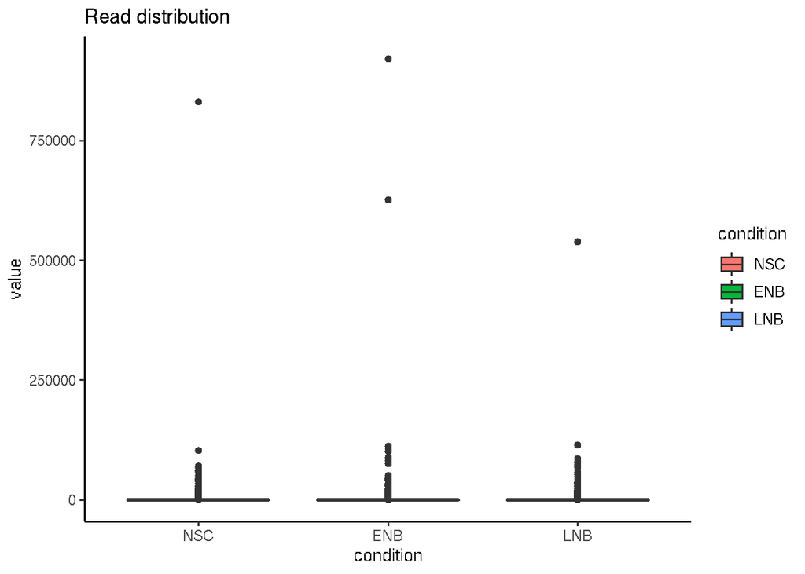

```r
df$condition<-df$variable
df$condition<-gsub("_1", "",df$condition)
df$condition<-gsub("_2", "",df$condition)
df$condition<-gsub("_3", "",df$condition)
df$condition <- factor(df$condition,
                       levels = c("NSC","ENB", "LNB"))

ggplot(df, aes(x=condition, y=value, fill=condition)) +
  geom_boxplot()+
  theme_classic()+
  labs(title="Read distribution")
```

- Definimos las condiciones:

```r
condition<-factor(rep(c("NSC","ENB", "LNB"), each=3),
                  levels = c("NSC","ENB", "LNB"))
levels(condition)
```

```
## [1] "NSC" "ENB" "LNB"
```

```r
condition
```

```
## [1] NSC NSC NSC ENB ENB ENB LNB LNB LNB
## Levels: NSC ENB LNB
```

- Armamos el objeto para trabajar con edgeR:

```r
y <- DGEList(counts=counts, group=condition)
keep <- filterByExpr(y)
summary(keep)
```

```
##    Mode   FALSE    TRUE
## logical   24101   14823
```

```r
y <- y[keep, , keep.lib.sizes=FALSE]
y<-calcNormFactors(y)
y$samples
```

```
##       group lib.size norm.factors
## NSC_1   NSC  9507090    1.1022613
## NSC_2   NSC  8654186    0.9492715
## NSC_3   NSC  7809603    1.0800020
## ENB_1   ENB  8028827    0.9210250
## ENB_2   ENB  4927324    1.0331455
## ENB_3   ENB  9974904    0.9818950
## LNB_1   LNB  5233032    1.0024976
## LNB_2   LNB  9114095    1.0095833
## LNB_3   LNB  3843948    0.9357870
```

- Estimamos dispersión Es importante notar que acá se consideran todas las muestras juntas *¿Hay alguna diferencia en los valores?*

## La matriz de diseño

Aquí tenemos uno de los pasos más oscuros en el workflow, armar la matriz de diseño. Aunque la notación es un poco inentendible, simplemente asigna 0 y 1 a las diferentes condiciones. Usando esta notación se toma la primera condicion como “control”, todo se comparará a ese factor.

**En este punto es donde se presenta la estrategia para analizar diferentes diseños experimentales**

```r
design <- model.matrix(~y$samples$group)
rownames(design) <- colnames(y)
design
```

```
##       (Intercept) y$samples$groupENB y$samples$groupLNB
## NSC_1           1                  0                  0
## NSC_2           1                  0                  0
## NSC_3           1                  0                  0
## ENB_1           1                  1                  0
## ENB_2           1                  1                  0
## ENB_3           1                  1                  0
## LNB_1           1                  0                  1
## LNB_2           1                  0                  1
## LNB_3           1                  0                  1
## attr(,"assign")
## [1] 0 1 1
## attr(,"contrasts")
## attr(,"contrasts")$`y$samples$group`
## [1] "contr.treatment"
```

```r
y <- estimateDisp(y)
```

```
## Using classic mode.
```

```r
y$common.dispersion
```

```
## [1] 0.2520499
```

```r
sqrt(y$common.dispersion)
```

```
## [1] 0.5020458
```

```r
summary(y$trended.dispersion)
```

```
##    Min. 1st Qu.  Median    Mean 3rd Qu.    Max.
## 0.07292 0.09527 0.17508 0.32939 0.54363 0.95258
```

```r
summary(y$tagwise.dispersion)
```

```
##    Min. 1st Qu.  Median    Mean 3rd Qu.    Max.
##  0.0284  0.0738  0.1575  0.3649  0.4415  4.8893
```

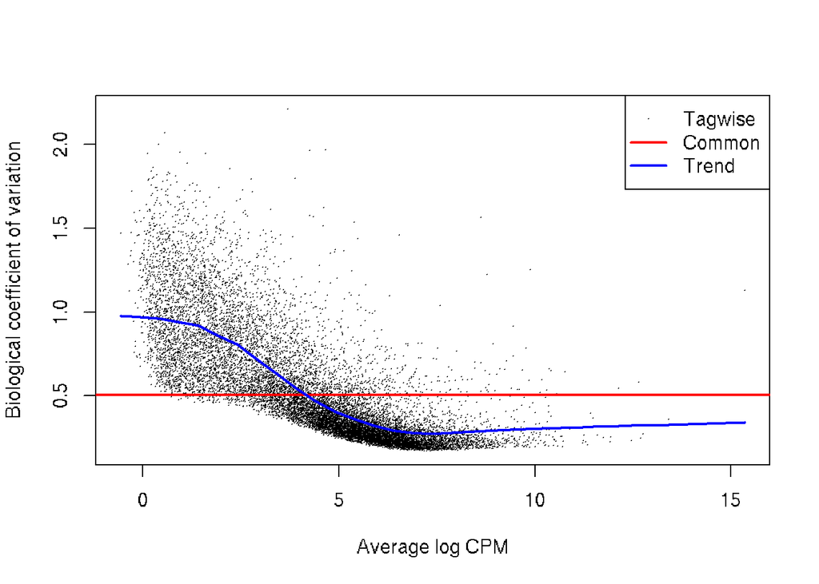

```r
plotBCV(y)
```

- Inspeccionamos la relación entre las réplicas:

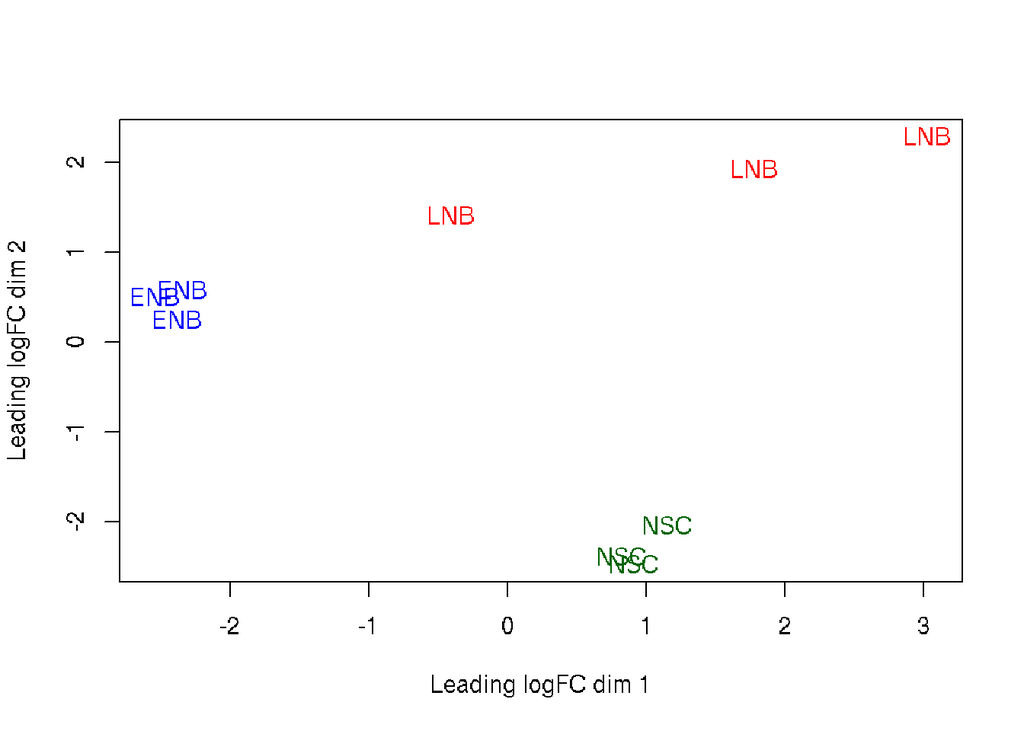

```r
plotMDS(y, labels=condition,
col=c("darkgreen","blue","red")[factor(condition)])
```

- Ahora establecemos el modelo:

```r
fit<-glmFit(y,design)
```

- Una vez que ajustamos el modelo, usando la matrix de diseño

```r
design
```

```
##       (Intercept) y$samples$groupENB y$samples$groupLNB
## NSC_1           1                  0                  0
## NSC_2           1                  0                  0
## NSC_3           1                  0                  0
## ENB_1           1                  1                  0
## ENB_2           1                  1                  0
## ENB_3           1                  1                  0
## LNB_1           1                  0                  1
## LNB_2           1                  0                  1
## LNB_3           1                  0                  1
## attr(,"assign")
## [1] 0 1 1
## attr(,"contrasts")
## attr(,"contrasts")$`y$samples$group`
## [1] "contr.treatment"
```

- podemos testear de a pares (como en la práctica anterior):

```r
lrtENB<-glmLRT(fit, coef=2)
head(topTags(lrtENB))
```

```
## Coefficient:  y$samples$groupENB
##                         logFC   logCPM       LR       PValue          FDR
## ENSMUSG00000042988 -10.588772 5.004263 219.0069 1.489371e-49 1.317667e-45
## ENSMUSG00000021702  -9.595219 6.443307 218.6544 1.777868e-49 1.317667e-45
## ENSMUSG00000052551   3.794558 6.669253 124.9370 5.253773e-29 2.595889e-25
## ENSMUSG00000030772  -4.034372 8.099080 118.6732 1.234865e-27 3.853661e-24
## ENSMUSG00000020181   3.622366 6.977991 118.5714 1.299892e-27 3.853661e-24
## ENSMUSG00000053399  -9.758541 4.190970 109.2598 1.423493e-25 3.516738e-22
```

```r
summary(decideTests(lrtENB))
```

```
##        y$samples$groupENB
## Down                 1975
## NotSig              11338
## Up                   1510
```

```r
lrtLNB<-glmLRT(fit, coef=3)
head(topTags(lrtLNB))
```

```
## Coefficient:  y$samples$groupLNB
##                         logFC   logCPM       LR       PValue          FDR
## ENSMUSG00000042988 -12.476063 5.004263 213.5722 2.283230e-48 3.384432e-44
## ENSMUSG00000021702  -8.801620 6.443307 200.4712 1.648213e-45 1.221573e-41
## ENSMUSG00000041859  -4.082094 6.732841 180.4869 3.794183e-41 1.874706e-37
## ENSMUSG00000020808  -3.095993 6.674769 162.7624 2.819176e-37 1.044716e-33
## ENSMUSG00000040204  -4.160297 7.599879 155.2017 1.265056e-35 3.750384e-32
## ENSMUSG00000006398  -3.707138 7.388052 152.9571 3.914342e-35 9.670382e-32
```

```r
summary(decideTests(lrtLNB))
```

```
##        y$samples$groupLNB
## Down                 1162
## NotSig              12362
## Up                   1299
```

- O los 2 a la vez, de manera de buscar genes que se hayan perturbado en algunas de las condiciones: *(ANOVA-like)*

```r
lrt<-glmLRT(fit, coef=2:3);
head(topTags(lrt))
```

```
## Coefficient:  y$samples$groupENB y$samples$groupLNB
##                    logFC.y.samples.groupENB logFC.y.samples.groupLNB   logCPM
## ENSMUSG00000042988              -10.5887722               -12.476063 5.004263
## ENSMUSG00000021702               -9.5952194                -8.801620 6.443307
## ENSMUSG00000053399               -9.7585407               -11.648580 4.190970
## ENSMUSG00000030772               -4.0343721                -3.864034 8.099080
## ENSMUSG00000020808                0.2179196                -3.095993 6.674769
## ENSMUSG00000041859               -1.6406290                -4.082094 6.732841
##                          LR       PValue          FDR
## ENSMUSG00000042988 403.1847 2.815545e-88 4.173483e-84
## ENSMUSG00000021702 393.3650 3.818355e-86 2.829974e-82
## ENSMUSG00000053399 204.1799 4.601575e-45 2.273638e-41
## ENSMUSG00000030772 197.0769 1.604310e-43 5.945173e-40
## ENSMUSG00000020808 195.8101 3.022503e-43 8.960511e-40
## ENSMUSG00000041859 190.2021 4.990530e-42 1.232910e-38
```

```r
summary(decideTests(lrt))
```

```
##        y$samples$groupLNB-y$samples$groupENB
## NotSig                                 10448
## Sig                                     4375
```

Ahora con estos resultados, podemos empezar a hacernos preguntas más interesantes:

- *¿Son los mismos genes afectados?*

## Clustering no supervisado

Podemos seleccionar aquellos genes más afectadoss (de acuerdo por ejemplo al FDR) y de ahi graficarlos en forma de heatmap. Podemos agruparlos usando un clustering jerarquico y de ahi extraer diferentes grupos para analizarlos, por ejemplo, con Gene Ontology

Tambien podrias ser por ejemplo, buscar motivos regulatorios comunes dentro de los grupos

```r
tt<-topTags(lrt, n = nrow(lrt$fitted.values))
head(tt)
```

```
## Coefficient:  y$samples$groupENB y$samples$groupLNB
##                    logFC.y.samples.groupENB logFC.y.samples.groupLNB   logCPM
## ENSMUSG00000042988              -10.5887722               -12.476063 5.004263
## ENSMUSG00000021702               -9.5952194                -8.801620 6.443307
## ENSMUSG00000053399               -9.7585407               -11.648580 4.190970
## ENSMUSG00000030772               -4.0343721                -3.864034 8.099080
## ENSMUSG00000020808                0.2179196                -3.095993 6.674769
## ENSMUSG00000041859               -1.6406290                -4.082094 6.732841
##                          LR       PValue          FDR
## ENSMUSG00000042988 403.1847 2.815545e-88 4.173483e-84
## ENSMUSG00000021702 393.3650 3.818355e-86 2.829974e-82
## ENSMUSG00000053399 204.1799 4.601575e-45 2.273638e-41
## ENSMUSG00000030772 197.0769 1.604310e-43 5.945173e-40
## ENSMUSG00000020808 195.8101 3.022503e-43 8.960511e-40
## ENSMUSG00000041859 190.2021 4.990530e-42 1.232910e-38
```

```r
topis<-which(tt$table$FDR < 0.00001); length(topis)
```

```
## [1] 840
```

```r
fc<-tt$table[topis,][,1:2]
```

- Hacemos el heatmap:

```r
paletteLength <- 50
myColor <- colorRampPalette(c("blue","white", "red"))(paletteLength)
myBreaks <- c(seq(min(fc), 0,
              length.out=ceiling(paletteLength/2) + 1),
              seq(max(fc)/paletteLength,
              max(fc),
              length.out=floor(paletteLength/2)))
```

- Decido separar en 10 grupos:

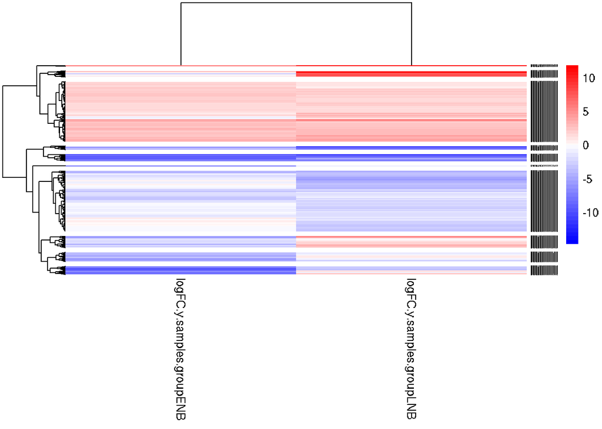

```r
heat<-pheatmap(fc,
         fontsize_col= 10,
         fontsize_row=1,
         myColor,
         breaks=myBreaks,
         cluster_rows = TRUE,
         cutree_rows=10)
```

- Extraemos los genes por sus grupos:

```r
hc <-heat$tree_row
lbl <- cutree(hc, 10)
table(lbl)
```

```
## lbl
##   1   2   3   4   5   6   7   8   9  10
##  34 306 302  17  30   5  40  59  46   1
```

## Un contraste alternativo: cada condición es independiente

Ahora la matriz debe ser definida de esta manera:

```r
designAlt <- model.matrix(~0+y$samples$group)
rownames(designAlt ) <- colnames(y)
designAlt
```

```
##       y$samples$groupNSC y$samples$groupENB y$samples$groupLNB
## NSC_1                  1                  0                  0
## NSC_2                  1                  0                  0
## NSC_3                  1                  0                  0
## ENB_1                  0                  1                  0
## ENB_2                  0                  1                  0
## ENB_3                  0                  1                  0
## LNB_1                  0                  0                  1
## LNB_2                  0                  0                  1
## LNB_3                  0                  0                  1
## attr(,"assign")
## [1] 1 1 1
## attr(,"contrasts")
## attr(,"contrasts")$`y$samples$group`
## [1] "contr.treatment"
```

- Repetimos todos los pasos de estimar la dispersion, definir el modelo y testear por genes DE:

```r
y <- estimateDisp(y, design = designAlt)
y$common.dispersion
```

```
## [1] 0.2481241
```

```r
sqrt(y$common.dispersion)
```

```
## [1] 0.4981205
```

```r
summary(y$trended.dispersion)
```

```
##    Min. 1st Qu.  Median    Mean 3rd Qu.    Max.
## 0.07251 0.09458 0.17346 0.33119 0.54118 0.97988
```

```r
summary(y$tagwise.dispersion)
```

```
##    Min. 1st Qu.  Median    Mean 3rd Qu.    Max.
## 0.02814 0.07319 0.15598 0.37544 0.43503 5.91213
```

```r
levels(condition)
```

```
## [1] "NSC" "ENB" "LNB"
```

```r
fit <- glmQLFit(y, designAlt)

qlf_NvE <- glmQLFTest(fit,
                  contrast=c(1,-1,0))

head(topTags(qlf_NvE))
```

```
## Coefficient:  1*y$samples$groupNSC -1*y$samples$groupENB
##                        logFC   logCPM        F       PValue          FDR
## ENSMUSG00000052551 -3.795362 6.669242 165.6650 1.516937e-07 0.0006786033
## ENSMUSG00000042988 10.587312 5.004365 279.2349 1.678247e-07 0.0006786033
## ENSMUSG00000021136 -2.870971 6.930851 157.1453 1.947203e-07 0.0006786033
## ENSMUSG00000020181 -3.622852 6.977985 154.6429 2.100496e-07 0.0006786033
## ENSMUSG00000030772  4.034346 8.099090 147.8527 2.595508e-07 0.0006786033
## ENSMUSG00000041642 -2.739942 7.216218 141.8008 3.158981e-07 0.0006786033
```

```r
summary(decideTests(qlf_NvE))
```

```
##        1*y$samples$groupNSC -1*y$samples$groupENB
## Down                                         1090
## NotSig                                      12547
## Up                                           1186
```

```r
qlfE_v_L <- glmQLFTest(fit,
                  contrast=c(0, 1,-1))
head(topTags(qlfE_v_L))
```

```
## Coefficient:  1*y$samples$groupENB -1*y$samples$groupLNB
##                       logFC   logCPM        F       PValue          FDR
## ENSMUSG00000020808 3.319039 6.674784 358.1186 3.713902e-09 5.505117e-05
## ENSMUSG00000062248 3.075306 6.272528 241.6960 2.495914e-08 1.609819e-04
## ENSMUSG00000006398 3.760817 7.388064 224.4943 3.559628e-08 1.609819e-04
## ENSMUSG00000017716 3.300729 6.789754 215.3656 4.344111e-08 1.609819e-04
## ENSMUSG00000012443 3.195863 7.034286 197.0052 6.653719e-08 1.972562e-04
## ENSMUSG00000028044 2.931031 6.497341 175.1128 1.166072e-07 2.880781e-04
```

```r
summary(decideTests(qlfE_v_L))
```

```
##        1*y$samples$groupENB -1*y$samples$groupLNB
## Down                                          504
## NotSig                                      13960
## Up                                            359
```